# Лабораторная работа №10

Администрирование локальных сетей

Ибрахим Мохсейн Алькамаль

1032225432@rudn.ru

Российский университет дружбы народов

2026-04-18

# Информация

## Докладчик

- Ибрахим Мохсейн Алькамаль
- Российский университет дружбы народов
- [GitHub](https://github.com/Ebrahimalkamal2027)

# Цель работы

- Освоение настройки прав доступа пользователей к ресурсам сети

# Выполнение лабораторной работы

## Анализ топологии сети

- Добавлен ноутбук администратора в сеть
- Подключён к коммутатору для настройки доступа

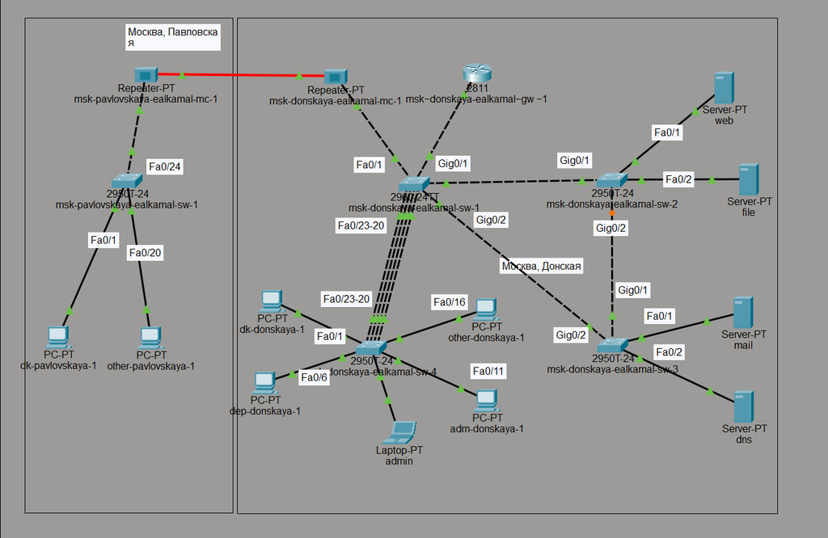

Рисунок 1: Логическая топология сети с серверами и сегментацией VLAN

## Настройка IP-параметров администратора

- Назначен IP-адрес: 10.128.6.200
- Установлена маска: 255.255.255.0
- Задан шлюз: 10.128.6.1
- Указан DNS: 10.128.0.5

[figure not shown]

Рисунок 2: Настройка статических IP-параметров администратора

## Создание ACL для web-сервера

- Создан расширенный ACL: servers-out
- Добавлено правило разрешения HTTP (TCP 80)
- Указан адрес сервера: 10.128.0.2

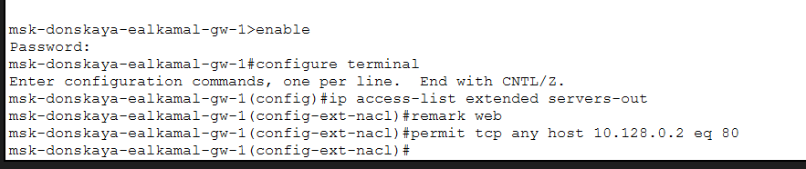

Рисунок 3: Создание ACL и разрешение HTTP-доступа к web-серверу

## Привязка ACL к интерфейсу маршрутизатора

- Выбран подинтерфейс: f0/0.3
- Применён ACL servers-out
- Направление: исходящий трафик (out)

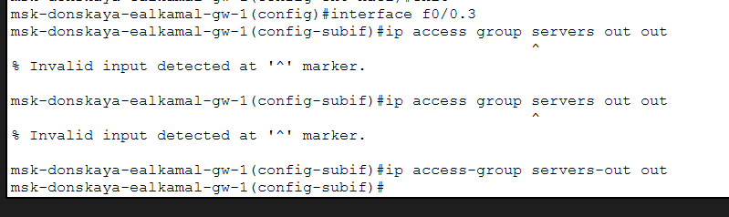

Рисунок 4: Привязка ACL к интерфейсу маршрутизатора

## Проверка доступа к web-серверу

- Открыт браузер на клиенте
- Введён IP-адрес сервера
- Проверен доступ по HTTP

[figure not shown]

Рисунок 5: Проверка доступа к web-серверу через HTTP

## Настройка дополнительных прав администратора

- Добавлено правило FTP для администратора
- Добавлено правило Telnet для администратора
- Указан IP администратора: 10.128.6.200

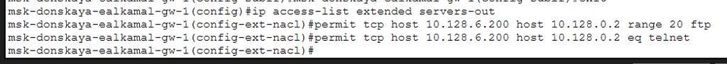

Рисунок 6: Разрешение FTP и Telnet для администратора

## Проверка FTP-доступа администратора

- Выполнено подключение по FTP
- Указан адрес сервера
- Успешная аутентификация

[figure not shown]

Рисунок 7: Успешное FTP-подключение администратора

## Проверка ограничения доступа для пользователей

- Выполнена попытка FTP с обычного ПК
- Соединение не установлено
- Доступ ограничен ACL

[figure not shown]

Рисунок 8: Ограничение FTP-доступа для обычных пользователей

## Настройка доступа к файловому серверу

- Добавлено правило SMB (порт 445)
- Разрешён доступ внутренней сети
- Разрешён FTP для всех

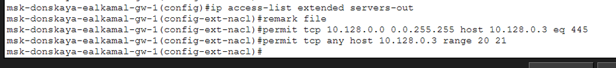

Рисунок 9: Настройка доступа к файловому серверу

## Настройка доступа к почтовому серверу

- Разрешён SMTP
- Разрешён POP3
- Указан адрес сервера: 10.128.0.4

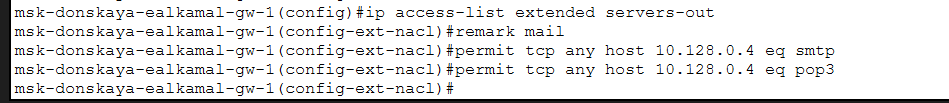

Рисунок 10: Настройка доступа к почтовому серверу

## Настройка доступа к DNS-серверу

- Разрешён UDP порт 53
- Ограничение для внутренней сети
- Указан DNS сервер

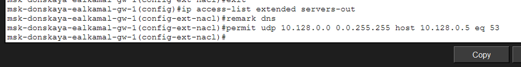

Рисунок 11: Настройка доступа к DNS-серверу

## Проверка доступа по доменному имени

- Введено доменное имя в браузере
- Проверено разрешение DNS
- Доступ к web-серверу выполнен

[figure not shown]

Рисунок 12: Доступ к web-серверу по доменному имени

## Разрешение ICMP-трафика

- Добавлено правило ICMP
- Размещено в начале ACL
- Используется для проверки доступности

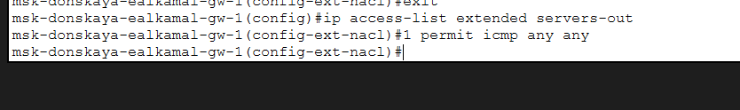

Рисунок 13: Добавление правила ICMP в ACL

## Проверка списка ACL

- Выполнена команда show access-lists
- Отображены правила ACL
- Показано количество совпадений

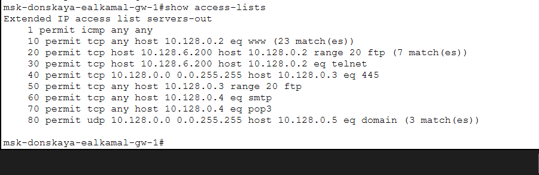

Рисунок 14: Вывод списка ACL и статистики совпадений

## Ограничение доступа для сети Other

- Создан ACL other-in
- Разрешён доступ только администратору
- Применён к интерфейсу f0/0.104

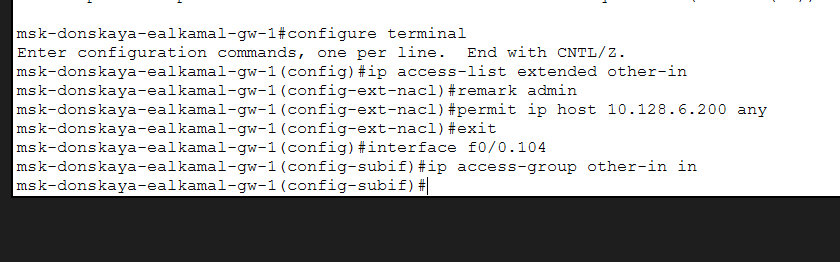

Рисунок 15: Настройка ACL для сети Other

## Ограничение доступа к сети управления

- Создан ACL management-out
- Разрешён доступ только администратору
- Применён к интерфейсу f0/0.2

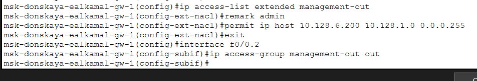

Рисунок 16: Настройка доступа к сети управления

# Выводы

- Настроены расширенные списки ACL
- Разграничены права доступа пользователей
- Реализована фильтрация по протоколам и портам
- Обеспечена изоляция сетей
- Предоставлены административные привилегии одному устройству